# Risk Factor Analysis

## Outcome Variable

**Outcome Variable:** wasted

## Predictor Variables

**Intervention Variable:** exclfeed36

**Adjustment Set:**

unadjusted

## Stratifying Variables

The analysis was stratified on these variable(s):

- agecat
- studyid
- country

## Data Summary

| agecat | studyid | country | exclfeed36 | wasted | n_cell | n |
| --- | --- | --- | --- | --- | --- | --- |
| Birth | ki0047075b-MAL-ED | BANGLADESH | 0 | 0 | 143 | 230 |
| Birth | ki0047075b-MAL-ED | BANGLADESH | 0 | 1 | 29 | 230 |
| Birth | ki0047075b-MAL-ED | BANGLADESH | 1 | 0 | 48 | 230 |
| Birth | ki0047075b-MAL-ED | BANGLADESH | 1 | 1 | 10 | 230 |
| Birth | ki0047075b-MAL-ED | BRAZIL | 0 | 0 | 159 | 177 |
| Birth | ki0047075b-MAL-ED | BRAZIL | 0 | 1 | 6 | 177 |
| Birth | ki0047075b-MAL-ED | BRAZIL | 1 | 0 | 12 | 177 |
| Birth | ki0047075b-MAL-ED | BRAZIL | 1 | 1 | 0 | 177 |
| Birth | ki0047075b-MAL-ED | INDIA | 0 | 0 | 157 | 195 |
| Birth | ki0047075b-MAL-ED | INDIA | 0 | 1 | 33 | 195 |
| Birth | ki0047075b-MAL-ED | INDIA | 1 | 0 | 5 | 195 |
| Birth | ki0047075b-MAL-ED | INDIA | 1 | 1 | 0 | 195 |
| Birth | ki0047075b-MAL-ED | NEPAL | 0 | 0 | 136 | 167 |
| Birth | ki0047075b-MAL-ED | NEPAL | 0 | 1 | 20 | 167 |
| Birth | ki0047075b-MAL-ED | NEPAL | 1 | 0 | 11 | 167 |
| Birth | ki0047075b-MAL-ED | NEPAL | 1 | 1 | 0 | 167 |
| Birth | ki0047075b-MAL-ED | PERU | 0 | 0 | 245 | 266 |
| Birth | ki0047075b-MAL-ED | PERU | 0 | 1 | 6 | 266 |
| Birth | ki0047075b-MAL-ED | PERU | 1 | 0 | 15 | 266 |
| Birth | ki0047075b-MAL-ED | PERU | 1 | 1 | 0 | 266 |
| Birth | ki0047075b-MAL-ED | SOUTH AFRICA | 0 | 0 | 220 | 234 |
| Birth | ki0047075b-MAL-ED | SOUTH AFRICA | 0 | 1 | 14 | 234 |
| Birth | ki0047075b-MAL-ED | SOUTH AFRICA | 1 | 0 | 0 | 234 |
| Birth | ki0047075b-MAL-ED | SOUTH AFRICA | 1 | 1 | 0 | 234 |
| Birth | ki0047075b-MAL-ED | TANZANIA, UNITED REPUBLIC OF | 0 | 0 | 113 | 116 |
| Birth | ki0047075b-MAL-ED | TANZANIA, UNITED REPUBLIC OF | 0 | 1 | 2 | 116 |
| Birth | ki0047075b-MAL-ED | TANZANIA, UNITED REPUBLIC OF | 1 | 0 | 1 | 116 |
| Birth | ki0047075b-MAL-ED | TANZANIA, UNITED REPUBLIC OF | 1 | 1 | 0 | 116 |
| Birth | ki1000108-CMC-V-BCS-2002 | INDIA | 0 | 0 | 0 | 3 |
| Birth | ki1000108-CMC-V-BCS-2002 | INDIA | 0 | 1 | 0 | 3 |

[output cut: 150 more lines]

The following strata were considered:

- agecat: 24 months, studyid: ki0047075b-MAL-ED, country: BANGLADESH
- agecat: 24 months, studyid: ki0047075b-MAL-ED, country: BRAZIL
- agecat: 24 months, studyid: ki0047075b-MAL-ED, country: INDIA
- agecat: 24 months, studyid: ki0047075b-MAL-ED, country: NEPAL
- agecat: 24 months, studyid: ki0047075b-MAL-ED, country: PERU
- agecat: 24 months, studyid: ki0047075b-MAL-ED, country: SOUTH AFRICA
- agecat: 24 months, studyid: ki0047075b-MAL-ED, country: TANZANIA, UNITED REPUBLIC OF
- agecat: 24 months, studyid: ki1000108-CMC-V-BCS-2002, country: INDIA
- agecat: 24 months, studyid: ki1000108-IRC, country: INDIA
- agecat: 24 months, studyid: ki1017093b-PROVIDE, country: BANGLADESH
- agecat: 24 months, studyid: ki1101329-Keneba, country: GAMBIA
- agecat: 24 months, studyid: ki1113344-GMS-Nepal, country: NEPAL
- agecat: 24 months, studyid: ki1148112-LCNI-5, country: MALAWI
- agecat: 24 months, studyid: kiGH5241-JiVitA-3, country: BANGLADESH
- agecat: 24 months, studyid: kiGH5241-JiVitA-4, country: BANGLADESH
- agecat: 6 months, studyid: ki0047075b-MAL-ED, country: BANGLADESH
- agecat: 6 months, studyid: ki0047075b-MAL-ED, country: BRAZIL
- agecat: 6 months, studyid: ki0047075b-MAL-ED, country: INDIA
- agecat: 6 months, studyid: ki0047075b-MAL-ED, country: NEPAL
- agecat: 6 months, studyid: ki0047075b-MAL-ED, country: PERU
- agecat: 6 months, studyid: ki0047075b-MAL-ED, country: SOUTH AFRICA
- agecat: 6 months, studyid: ki0047075b-MAL-ED, country: TANZANIA, UNITED REPUBLIC OF
- agecat: 6 months, studyid: ki1000108-CMC-V-BCS-2002, country: INDIA
- agecat: 6 months, studyid: ki1000108-IRC, country: INDIA
- agecat: 6 months, studyid: ki1000109-EE, country: PAKISTAN
- agecat: 6 months, studyid: ki1000304b-SAS-FoodSuppl, country: INDIA
- agecat: 6 months, studyid: ki1017093b-PROVIDE, country: BANGLADESH
- agecat: 6 months, studyid: ki1101329-Keneba, country: GAMBIA
- agecat: 6 months, studyid: ki1113344-GMS-Nepal, country: NEPAL
- agecat: 6 months, studyid: ki1148112-LCNI-5, country: MALAWI
- agecat: 6 months, studyid: kiGH5241-JiVitA-3, country: BANGLADESH
- agecat: 6 months, studyid: kiGH5241-JiVitA-4, country: BANGLADESH
- agecat: Birth, studyid: ki0047075b-MAL-ED, country: BANGLADESH
- agecat: Birth, studyid: ki0047075b-MAL-ED, country: BRAZIL
- agecat: Birth, studyid: ki0047075b-MAL-ED, country: INDIA
- agecat: Birth, studyid: ki0047075b-MAL-ED, country: NEPAL
- agecat: Birth, studyid: ki0047075b-MAL-ED, country: PERU
- agecat: Birth, studyid: ki0047075b-MAL-ED, country: SOUTH AFRICA
- agecat: Birth, studyid: ki0047075b-MAL-ED, country: TANZANIA, UNITED REPUBLIC OF
- agecat: Birth, studyid: ki1000108-CMC-V-BCS-2002, country: INDIA
- agecat: Birth, studyid: ki1000108-IRC, country: INDIA
- agecat: Birth, studyid: ki1000109-EE, country: PAKISTAN
- agecat: Birth, studyid: ki1101329-Keneba, country: GAMBIA
- agecat: Birth, studyid: kiGH5241-JiVitA-3, country: BANGLADESH
- agecat: Birth, studyid: kiGH5241-JiVitA-4, country: BANGLADESH

### Dropped Strata

Some strata were dropped due to rare outcomes:

- agecat: Birth, studyid: ki0047075b-MAL-ED, country: BRAZIL
- agecat: Birth, studyid: ki0047075b-MAL-ED, country: INDIA
- agecat: Birth, studyid: ki0047075b-MAL-ED, country: NEPAL
- agecat: Birth, studyid: ki0047075b-MAL-ED, country: PERU
- agecat: Birth, studyid: ki0047075b-MAL-ED, country: SOUTH AFRICA
- agecat: Birth, studyid: ki0047075b-MAL-ED, country: TANZANIA, UNITED REPUBLIC OF
- agecat: Birth, studyid: ki1000108-CMC-V-BCS-2002, country: INDIA
- agecat: Birth, studyid: ki1000108-IRC, country: INDIA
- agecat: Birth, studyid: ki1000109-EE, country: PAKISTAN
- agecat: Birth, studyid: kiGH5241-JiVitA-4, country: BANGLADESH
- agecat: 6 months, studyid: ki0047075b-MAL-ED, country: BANGLADESH
- agecat: 6 months, studyid: ki0047075b-MAL-ED, country: BRAZIL
- agecat: 6 months, studyid: ki0047075b-MAL-ED, country: INDIA
- agecat: 6 months, studyid: ki0047075b-MAL-ED, country: NEPAL
- agecat: 6 months, studyid: ki0047075b-MAL-ED, country: PERU
- agecat: 6 months, studyid: ki0047075b-MAL-ED, country: SOUTH AFRICA
- agecat: 6 months, studyid: ki0047075b-MAL-ED, country: TANZANIA, UNITED REPUBLIC OF
- agecat: 6 months, studyid: ki1000108-CMC-V-BCS-2002, country: INDIA
- agecat: 6 months, studyid: ki1000108-IRC, country: INDIA
- agecat: 6 months, studyid: ki1000304b-SAS-FoodSuppl, country: INDIA
- agecat: 6 months, studyid: ki1017093b-PROVIDE, country: BANGLADESH
- agecat: 6 months, studyid: ki1148112-LCNI-5, country: MALAWI
- agecat: 24 months, studyid: ki0047075b-MAL-ED, country: BRAZIL
- agecat: 24 months, studyid: ki0047075b-MAL-ED, country: INDIA
- agecat: 24 months, studyid: ki0047075b-MAL-ED, country: NEPAL
- agecat: 24 months, studyid: ki0047075b-MAL-ED, country: PERU
- agecat: 24 months, studyid: ki0047075b-MAL-ED, country: SOUTH AFRICA
- agecat: 24 months, studyid: ki0047075b-MAL-ED, country: TANZANIA, UNITED REPUBLIC OF
- agecat: 24 months, studyid: ki1000108-CMC-V-BCS-2002, country: INDIA
- agecat: 24 months, studyid: ki1000108-IRC, country: INDIA
- agecat: 24 months, studyid: ki1148112-LCNI-5, country: MALAWI

## Methods Detail

We’re interested in the causal parameters $E[Y_a]$ for all values of $a \in \mathcal{A}$. These parameters represent the mean outcome if, possibly contrary to fact, we intervened to set all units to have $A=a$. Under the randomization and positivity assumptions, these are identified by the statistical parameters $\psi_a=E_W[E_{Y|A,W}(Y|A=a,W)]$. In addition, we’re interested in the mean of $Y$, $E[Y]$ under no intervention (the observed mean). We will estimate these parameters by using SuperLearner to fit the relevant likelihood factors – $E_{Y|A,W}(Y|A=a,W)$ and $p(A=a|W)$, and then updating our likelihood fit using a joint TMLE.

For unadjusted analyses ($W=\{\}$), initial likelihoods were estimated using Lrnr_glm to estimate the simple $E(Y|A)$ and Lrnr_mean to estimate $p(A)$. For adjusted analyses, a small library containing Lrnr_glmnet, Lrnr_xgboost, and Lrnr_mean was used.

Having estimated these parameters, we will then use the delta method to estimate relative risks and attributable risks relative to a prespecified baseline level of $A$.

# Results Detail

## Results Plots

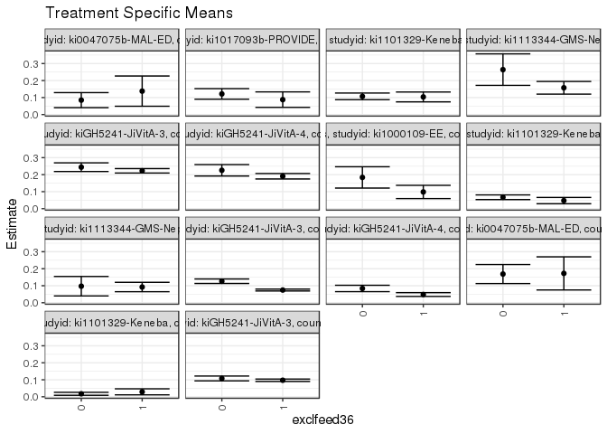

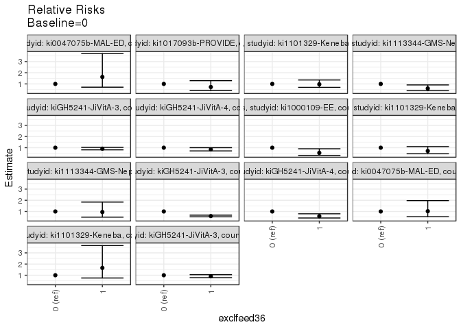

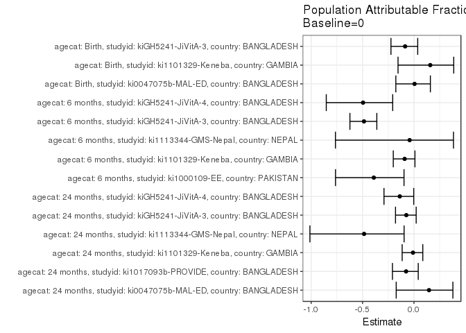

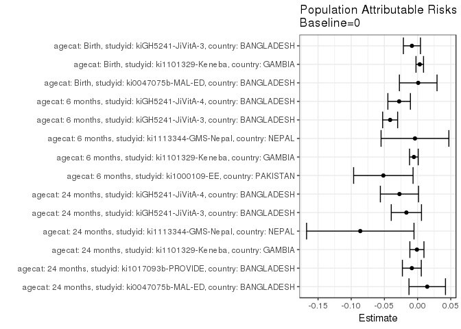

## Results Table

### Parameter: TSM

| agecat | studyid | country | intervention_level | baseline_level | estimate | ci_lower | ci_upper |
| --- | --- | --- | --- | --- | --- | --- | --- |
| Birth | ki0047075b-MAL-ED | BANGLADESH | 0 | NA | 0.1686047 | 0.1125297 | 0.2246796 |
| Birth | ki0047075b-MAL-ED | BANGLADESH | 1 | NA | 0.1724138 | 0.0749882 | 0.2698394 |
| Birth | ki1101329-Keneba | GAMBIA | 0 | NA | 0.0175029 | 0.0087196 | 0.0262862 |
| Birth | ki1101329-Keneba | GAMBIA | 1 | NA | 0.0289855 | 0.0112753 | 0.0466957 |
| Birth | kiGH5241-JiVitA-3 | BANGLADESH | 0 | NA | 0.1077425 | 0.0935838 | 0.1219012 |
| Birth | kiGH5241-JiVitA-3 | BANGLADESH | 1 | NA | 0.0972207 | 0.0902542 | 0.1041872 |
| 6 months | ki1000109-EE | PAKISTAN | 0 | NA | 0.1836735 | 0.1209932 | 0.2463537 |
| 6 months | ki1000109-EE | PAKISTAN | 1 | NA | 0.0982143 | 0.0591887 | 0.1372399 |
| 6 months | ki1101329-Keneba | GAMBIA | 0 | NA | 0.0670304 | 0.0533428 | 0.0807179 |
| 6 months | ki1101329-Keneba | GAMBIA | 1 | NA | 0.0473373 | 0.0288473 | 0.0658273 |
| 6 months | ki1113344-GMS-Nepal | NEPAL | 0 | NA | 0.0970874 | 0.0398543 | 0.1543204 |
| 6 months | ki1113344-GMS-Nepal | NEPAL | 1 | NA | 0.0921986 | 0.0646024 | 0.1197947 |
| 6 months | kiGH5241-JiVitA-3 | BANGLADESH | 0 | NA | 0.1263431 | 0.1130276 | 0.1396586 |
| 6 months | kiGH5241-JiVitA-3 | BANGLADESH | 1 | NA | 0.0745260 | 0.0689964 | 0.0800556 |
| 6 months | kiGH5241-JiVitA-4 | BANGLADESH | 0 | NA | 0.0838710 | 0.0650918 | 0.1026501 |
| 6 months | kiGH5241-JiVitA-4 | BANGLADESH | 1 | NA | 0.0481184 | 0.0371089 | 0.0591280 |
| 24 months | ki0047075b-MAL-ED | BANGLADESH | 0 | NA | 0.0849673 | 0.0406801 | 0.1292545 |
| 24 months | ki0047075b-MAL-ED | BANGLADESH | 1 | NA | 0.1379310 | 0.0489766 | 0.2268855 |
| 24 months | ki1017093b-PROVIDE | BANGLADESH | 0 | NA | 0.1214953 | 0.0905172 | 0.1524735 |
| 24 months | ki1017093b-PROVIDE | BANGLADESH | 1 | NA | 0.0878378 | 0.0421951 | 0.1334805 |
| 24 months | ki1101329-Keneba | GAMBIA | 0 | NA | 0.1071061 | 0.0876479 | 0.1265642 |
| 24 months | ki1101329-Keneba | GAMBIA | 1 | NA | 0.1037736 | 0.0747352 | 0.1328120 |
| 24 months | ki1113344-GMS-Nepal | NEPAL | 0 | NA | 0.2643678 | 0.1715992 | 0.3571364 |
| 24 months | ki1113344-GMS-Nepal | NEPAL | 1 | NA | 0.1576087 | 0.1203396 | 0.1948778 |
| 24 months | kiGH5241-JiVitA-3 | BANGLADESH | 0 | NA | 0.2439545 | 0.2184193 | 0.2694897 |
| 24 months | kiGH5241-JiVitA-3 | BANGLADESH | 1 | NA | 0.2225598 | 0.2095343 | 0.2355853 |
| 24 months | kiGH5241-JiVitA-4 | BANGLADESH | 0 | NA | 0.2256236 | 0.1919764 | 0.2592708 |
| 24 months | kiGH5241-JiVitA-4 | BANGLADESH | 1 | NA | 0.1905980 | 0.1745347 | 0.2066613 |

### Parameter: E(Y)

| agecat | studyid | country | intervention_level | baseline_level | estimate | ci_lower | ci_upper |
| --- | --- | --- | --- | --- | --- | --- | --- |
| Birth | ki0047075b-MAL-ED | BANGLADESH | NA | NA | 0.1695652 | 0.1209635 | 0.2181669 |
| Birth | ki1101329-Keneba | GAMBIA | NA | NA | 0.0207987 | 0.0127276 | 0.0288697 |
| Birth | kiGH5241-JiVitA-3 | BANGLADESH | NA | NA | 0.0992137 | 0.0929975 | 0.1054299 |
| 6 months | ki1000109-EE | PAKISTAN | NA | NA | 0.1320755 | 0.0975770 | 0.1665739 |
| 6 months | ki1101329-Keneba | GAMBIA | NA | NA | 0.0614525 | 0.0503239 | 0.0725811 |
| 6 months | ki1113344-GMS-Nepal | NEPAL | NA | NA | 0.0931559 | 0.0682937 | 0.1180181 |
| 6 months | kiGH5241-JiVitA-3 | BANGLADESH | NA | NA | 0.0849996 | 0.0797287 | 0.0902706 |
| 6 months | kiGH5241-JiVitA-4 | BANGLADESH | NA | NA | 0.0560882 | 0.0466363 | 0.0655401 |
| 24 months | ki0047075b-MAL-ED | BANGLADESH | NA | NA | 0.0995261 | 0.0590366 | 0.1400156 |
| 24 months | ki1017093b-PROVIDE | BANGLADESH | NA | NA | 0.1128472 | 0.0869854 | 0.1387090 |
| 24 months | ki1101329-Keneba | GAMBIA | NA | NA | 0.1060932 | 0.0899270 | 0.1222593 |
| 24 months | ki1113344-GMS-Nepal | NEPAL | NA | NA | 0.1780220 | 0.1428346 | 0.2132094 |
| 24 months | kiGH5241-JiVitA-3 | BANGLADESH | NA | NA | 0.2270683 | 0.2155455 | 0.2385912 |
| 24 months | kiGH5241-JiVitA-4 | BANGLADESH | NA | NA | 0.1983038 | 0.1835884 | 0.2130192 |

### Parameter: RR

| agecat | studyid | country | intervention_level | baseline_level | estimate | ci_lower | ci_upper |
| --- | --- | --- | --- | --- | --- | --- | --- |
| Birth | ki0047075b-MAL-ED | BANGLADESH | 0 | 0 | 1.0000000 | 1.0000000 | 1.0000000 |
| Birth | ki0047075b-MAL-ED | BANGLADESH | 1 | 0 | 1.0225922 | 0.5308176 | 1.9699699 |
| Birth | ki1101329-Keneba | GAMBIA | 0 | 0 | 1.0000000 | 1.0000000 | 1.0000000 |
| Birth | ki1101329-Keneba | GAMBIA | 1 | 0 | 1.6560386 | 0.7510872 | 3.6513251 |
| Birth | kiGH5241-JiVitA-3 | BANGLADESH | 0 | 0 | 1.0000000 | 1.0000000 | 1.0000000 |
| Birth | kiGH5241-JiVitA-3 | BANGLADESH | 1 | 0 | 0.9023429 | 0.7762575 | 1.0489080 |
| 6 months | ki1000109-EE | PAKISTAN | 0 | 0 | 1.0000000 | 1.0000000 | 1.0000000 |
| 6 months | ki1000109-EE | PAKISTAN | 1 | 0 | 0.5347222 | 0.3167039 | 0.9028240 |
| 6 months | ki1101329-Keneba | GAMBIA | 0 | 0 | 1.0000000 | 1.0000000 | 1.0000000 |
| 6 months | ki1101329-Keneba | GAMBIA | 1 | 0 | 0.7062061 | 0.4544784 | 1.0973614 |
| 6 months | ki1113344-GMS-Nepal | NEPAL | 0 | 0 | 1.0000000 | 1.0000000 | 1.0000000 |
| 6 months | ki1113344-GMS-Nepal | NEPAL | 1 | 0 | 0.9496454 | 0.4902690 | 1.8394520 |
| 6 months | kiGH5241-JiVitA-3 | BANGLADESH | 0 | 0 | 1.0000000 | 1.0000000 | 1.0000000 |
| 6 months | kiGH5241-JiVitA-3 | BANGLADESH | 1 | 0 | 0.5898700 | 0.5202368 | 0.6688236 |
| 6 months | kiGH5241-JiVitA-4 | BANGLADESH | 0 | 0 | 1.0000000 | 1.0000000 | 1.0000000 |
| 6 months | kiGH5241-JiVitA-4 | BANGLADESH | 1 | 0 | 0.5737199 | 0.4158873 | 0.7914514 |
| 24 months | ki0047075b-MAL-ED | BANGLADESH | 0 | 0 | 1.0000000 | 1.0000000 | 1.0000000 |
| 24 months | ki0047075b-MAL-ED | BANGLADESH | 1 | 0 | 1.6233422 | 0.7084127 | 3.7199216 |
| 24 months | ki1017093b-PROVIDE | BANGLADESH | 0 | 0 | 1.0000000 | 1.0000000 | 1.0000000 |
| 24 months | ki1017093b-PROVIDE | BANGLADESH | 1 | 0 | 0.7229730 | 0.4052732 | 1.2897224 |
| 24 months | ki1101329-Keneba | GAMBIA | 0 | 0 | 1.0000000 | 1.0000000 | 1.0000000 |
| 24 months | ki1101329-Keneba | GAMBIA | 1 | 0 | 0.9688861 | 0.6940338 | 1.3525857 |
| 24 months | ki1113344-GMS-Nepal | NEPAL | 0 | 0 | 1.0000000 | 1.0000000 | 1.0000000 |
| 24 months | ki1113344-GMS-Nepal | NEPAL | 1 | 0 | 0.5961720 | 0.3904828 | 0.9102094 |
| 24 months | kiGH5241-JiVitA-3 | BANGLADESH | 0 | 0 | 1.0000000 | 1.0000000 | 1.0000000 |
| 24 months | kiGH5241-JiVitA-3 | BANGLADESH | 1 | 0 | 0.9123006 | 0.8085009 | 1.0294267 |
| 24 months | kiGH5241-JiVitA-4 | BANGLADESH | 0 | 0 | 1.0000000 | 1.0000000 | 1.0000000 |
| 24 months | kiGH5241-JiVitA-4 | BANGLADESH | 1 | 0 | 0.8447611 | 0.7131305 | 1.0006882 |

### Parameter: PAR

| agecat | studyid | country | intervention_level | baseline_level | estimate | ci_lower | ci_upper |
| --- | --- | --- | --- | --- | --- | --- | --- |
| Birth | ki0047075b-MAL-ED | BANGLADESH | 0 | NA | 0.0009606 | -0.0273873 | 0.0293084 |
| Birth | ki1101329-Keneba | GAMBIA | 0 | NA | 0.0032958 | -0.0023859 | 0.0089774 |
| Birth | kiGH5241-JiVitA-3 | BANGLADESH | 0 | NA | -0.0085288 | -0.0213896 | 0.0043319 |
| 6 months | ki1000109-EE | PAKISTAN | 0 | NA | -0.0515980 | -0.0963814 | -0.0068146 |
| 6 months | ki1101329-Keneba | GAMBIA | 0 | NA | -0.0055779 | -0.0121068 | 0.0009510 |
| 6 months | ki1113344-GMS-Nepal | NEPAL | 0 | NA | -0.0039315 | -0.0550285 | 0.0471655 |
| 6 months | kiGH5241-JiVitA-3 | BANGLADESH | 0 | NA | -0.0413435 | -0.0526362 | -0.0300507 |
| 6 months | kiGH5241-JiVitA-4 | BANGLADESH | 0 | NA | -0.0277828 | -0.0447774 | -0.0107881 |
| 24 months | ki0047075b-MAL-ED | BANGLADESH | 0 | NA | 0.0145587 | -0.0129426 | 0.0420601 |
| 24 months | ki1017093b-PROVIDE | BANGLADESH | 0 | NA | -0.0086481 | -0.0228727 | 0.0055765 |
| 24 months | ki1101329-Keneba | GAMBIA | 0 | NA | -0.0010129 | -0.0116375 | 0.0096117 |
| 24 months | ki1113344-GMS-Nepal | NEPAL | 0 | NA | -0.0863458 | -0.1672969 | -0.0053948 |
| 24 months | kiGH5241-JiVitA-3 | BANGLADESH | 0 | NA | -0.0168861 | -0.0396627 | 0.0058905 |
| 24 months | kiGH5241-JiVitA-4 | BANGLADESH | 0 | NA | -0.0273198 | -0.0560849 | 0.0014454 |

### Parameter: PAF

| agecat | studyid | country | intervention_level | baseline_level | estimate | ci_lower | ci_upper |
| --- | --- | --- | --- | --- | --- | --- | --- |
| Birth | ki0047075b-MAL-ED | BANGLADESH | 0 | NA | 0.0056649 | -0.1763850 | 0.1595419 |
| Birth | ki1101329-Keneba | GAMBIA | 0 | NA | 0.1584597 | -0.1549517 | 0.3868228 |
| Birth | kiGH5241-JiVitA-3 | BANGLADESH | 0 | NA | -0.0859642 | -0.2239060 | 0.0364308 |
| 6 months | ki1000109-EE | PAKISTAN | 0 | NA | -0.3906705 | -0.7632405 | -0.0968240 |
| 6 months | ki1101329-Keneba | GAMBIA | 0 | NA | -0.0907674 | -0.2011495 | 0.0094710 |
| 6 months | ki1113344-GMS-Nepal | NEPAL | 0 | NA | -0.0422033 | -0.7639384 | 0.3842258 |
| 6 months | kiGH5241-JiVitA-3 | BANGLADESH | 0 | NA | -0.4863958 | -0.6230037 | -0.3612862 |
| 6 months | kiGH5241-JiVitA-4 | BANGLADESH | 0 | NA | -0.4953405 | -0.8529161 | -0.2067698 |
| 24 months | ki0047075b-MAL-ED | BANGLADESH | 0 | NA | 0.1462807 | -0.1727705 | 0.3785343 |
| 24 months | ki1017093b-PROVIDE | BANGLADESH | 0 | NA | -0.0766355 | -0.2093609 | 0.0415235 |
| 24 months | ki1101329-Keneba | GAMBIA | 0 | NA | -0.0095471 | -0.1148178 | 0.0857829 |
| 24 months | ki1113344-GMS-Nepal | NEPAL | 0 | NA | -0.4850291 | -1.0121484 | -0.0959984 |
| 24 months | kiGH5241-JiVitA-3 | BANGLADESH | 0 | NA | -0.0743659 | -0.1795789 | 0.0214626 |
| 24 months | kiGH5241-JiVitA-4 | BANGLADESH | 0 | NA | -0.1377672 | -0.2916738 | -0.0021991 |